# R Exercises - Load and plot multiple files

2021-02-04

In this typical exercise, we will learn how to read multiple files and plot them all together. This is the basic step of data analysis.

- Load the `tidyverse` and `readxl` libraries
- Store into `flist` the list of all `.xls` files in the `Data/` folder. Take a look at the `list.files()` function for this.
- Open one of the .xls files and study the structure of the file. The first group of 2-column data is the blank measurement, while the second group under the blank is the actual raw measurement. Working on the first file in the list, successively:
  - Read and store the blank data
  - Read and store the raw data
  - Combine them into a data.frame (or a tibble) containing the columns `w`, `blank`, `raw`, and `transmittance`, the later being the transmittance (in percent) with respect to the blank measurement.

The final table should look like this:

```
## # A tibble: 3,401 x 4
##        w blank   raw transmittance
##    <dbl> <dbl> <dbl>         <dbl>
##  1  4000   100  94.2          94.2
##  2  3999   100  94.3          94.3
##  3  3998   100  94.2          94.2
##  4  3997   100  94.2          94.2
##  5  3996   100  94.2          94.2
##  6  3995   100  94.2          94.2
##  7  3994   100  94.2          94.2
##  8  3993   100  94.2          94.2
##  9  3992   100  94.2          94.2
## 10  3991   100  94.2          94.2
## # … with 3,391 more rows
```

- Wrap this into a function `readFTIR()` that, given a file name, returns a data.frame (or a tibble) with the columns `w`, `blank`, `raw`, and `transmittance`. Test it on the first file in the list.
- Plot the first file in `flist`, and try to make your plot look like this:

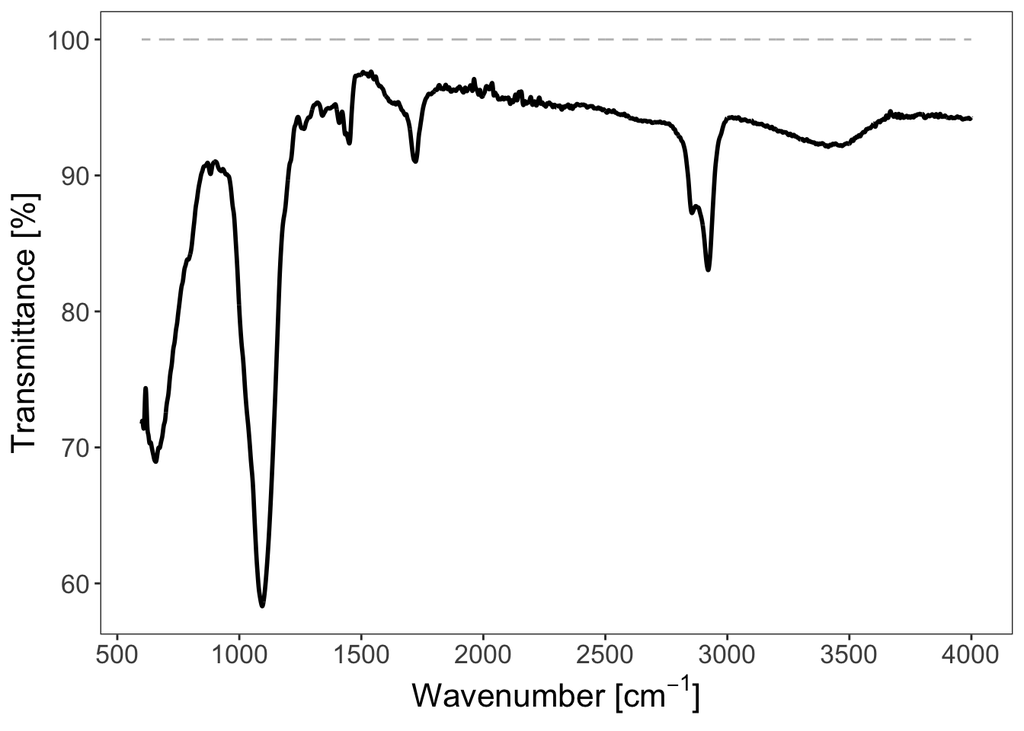

- Now we want to read all files in the list and store them in a tidy data.frame. For this we will start easy and use a `for` loop.
  - Define an empty data.frame called `df`
  - Define a `for` loop on all elements of `flist`
  - Then successively:
    - Read the current file with the above-defined function and store it in `tempdf`
    - Add the column `name` to `tempdf` containing the current file name. If needed, trim the path from the name string using `basename()`.
    - Stack `tempdf` below `df` by binding them row-wise.

The final table should look like this:

```
## # A tibble: 34,010 x 5
##        w blank   raw transmittance name
##    <dbl> <dbl> <dbl>         <dbl> <chr>
##  1  4000   100  94.2          94.2 sample_0_25C.xls
##  2  3999   100  94.3          94.3 sample_0_25C.xls
##  3  3998   100  94.2          94.2 sample_0_25C.xls
##  4  3997   100  94.2          94.2 sample_0_25C.xls
##  5  3996   100  94.2          94.2 sample_0_25C.xls
##  6  3995   100  94.2          94.2 sample_0_25C.xls
##  7  3994   100  94.2          94.2 sample_0_25C.xls
##  8  3993   100  94.2          94.2 sample_0_25C.xls
##  9  3992   100  94.2          94.2 sample_0_25C.xls
## 10  3991   100  94.2          94.2 sample_0_25C.xls
## # … with 34,000 more rows
```

- More advanced: you can do this without using a `for` loop using the `tidyverse`
- Plot all these files together using `ggplot2`. You can try several things, like:
  - Plot them all together in one frame with a color depending on the file name.
  - Plot them all on a different frame (facet_wrap) for each file.

The final plots should look like this:

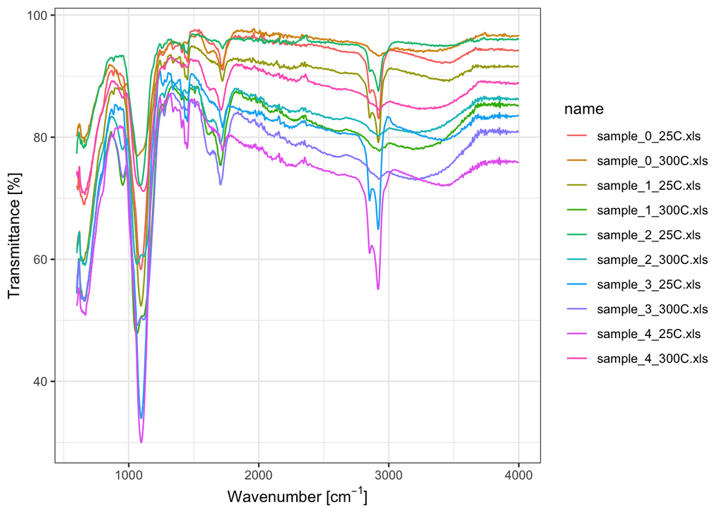

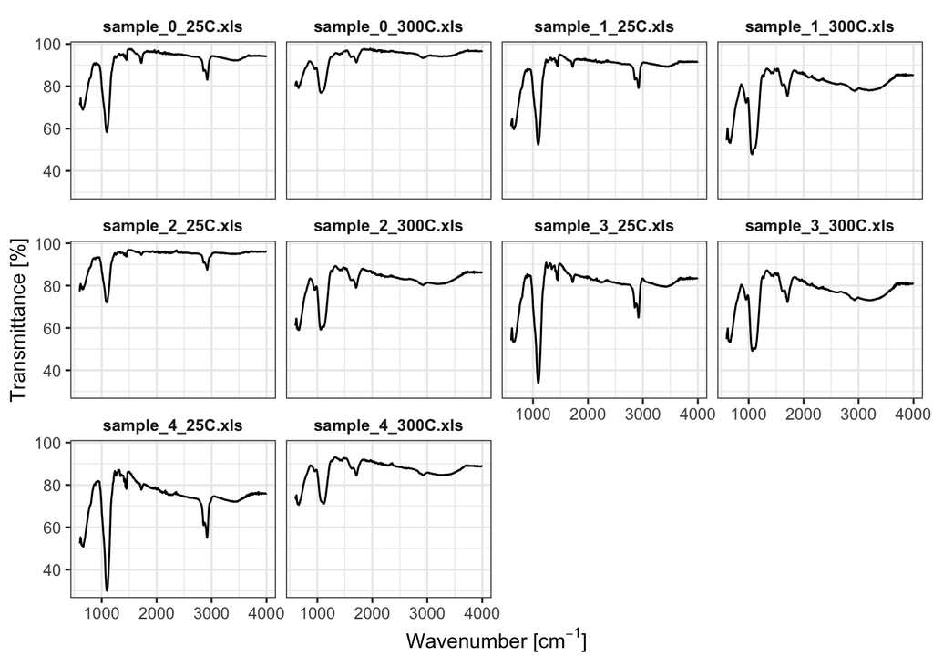

- You see in the file names that there are actually 5 samples with 2 temperatures for each. Based on the column `name` of the `df` data.frame, create the columns `sample` and `temperature` that contain *numerical values*. Think about using the function `gsub()` to replace (delete) text in a string, the `substr(string, start, end)` function to get a portion of a string.
- Now it is time to make nicer plots:
  - Make a grid plot showing the data evolution for each sample as a function of temperature
  - Make a grid plot with one frame per sample, and the two temperatures in different colors.

The final plots should look like this:

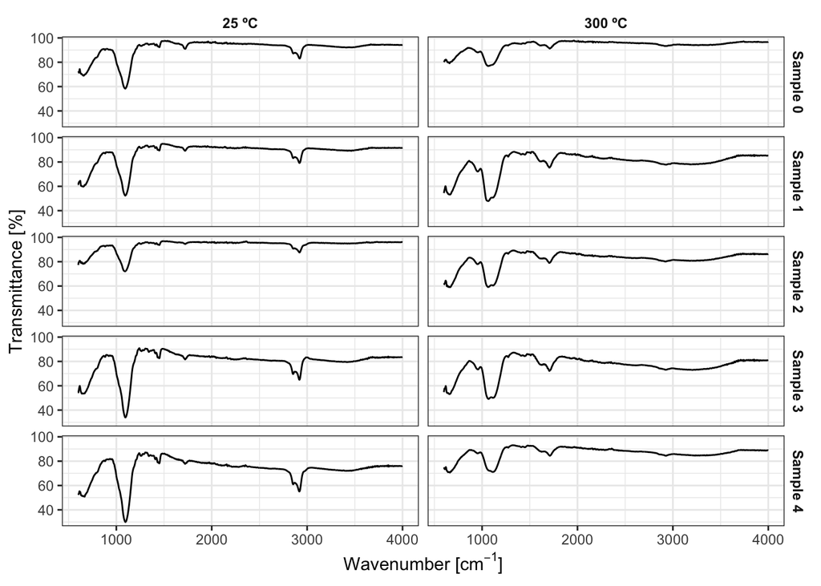

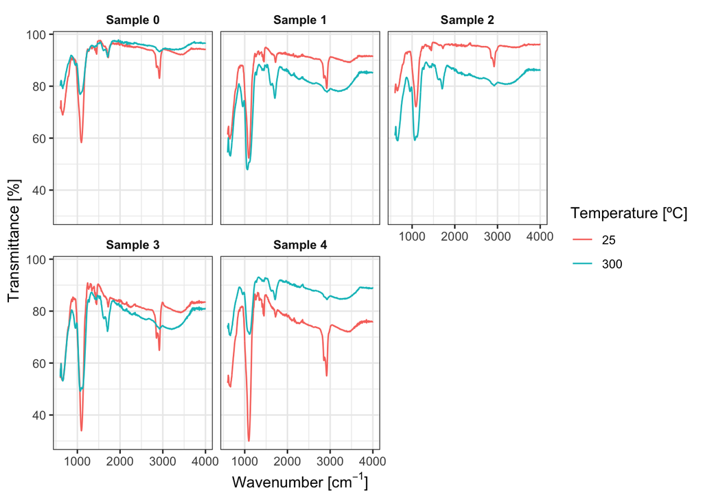